# Social Network Analysis

#### Betweenness centrality

Betweenness centrality is a way of detecting the amount of influence a node has over the flow of information in a graph. It is often used to find nodes that serve as a bridge from one part of a graph to another. We are using `betweenness()` to calculate this metric.

```r
betweenness(g, directed = FALSE, normalized = TRUE)
```

```
## Nicolas.Dussaillant           Ming.Chen             Rebecca      Nikita.Tejwani
##        0.0294740118        0.0435418612        0.0251452433        0.0085926963
##          Simon.Chen         Pooja.Addla             honglin                Karl
##        0.0007262164        0.3763953730        0.0023965142        0.0023965142
##          sicheng.xu     Jianan.Dingqian            Siyu.Lin         Ziqing.Yuan
##        0.0494268078        0.0539163814        0.0742400664        0.0367180205
##        Jingfei.Chen           Mina.Choi            Cleo.You                Deji
##        0.0160364146        0.0317382509        0.0023965142        0.0068860878
##          Kan.Yamane        YUNWEI.ZHANG            Madeline
##        0.0539163814        0.0367180205        0.0860877684
```

If you want to spend more time in centrality, check this out:

- exercise: https://www.sscnet.ucla.edu/soc/faculty/mcfarland/soc112/centrali.htm
- answers: https://www.sscnet.ucla.edu/soc/faculty/mcfarland/soc112/cent-ans.htm

#### Community detection

Then let’s take a look at the network structure through community detection. This method is very similar to clustering algorithm, which we have seen a few weeks ago. In a social network this is the idea that a large network can be broken down into smaller communinities/cliques. For example, if the network represents the social relationships of all the students at a school, a community/clique would be a friendship group.

There are many ways to approach community detection in networks. I am not going to go into the maths in too much detail but we are going to choose a modularity optimisation method – greedy modularity maximization. Modularity is a measure of the extent to which like is connected to like in a network. The algorithm we will chose is already implemented for us in `igraph`, which makes its implementation very easy! Read more about different ways to cluster in `igraph` documentation: https://igraph.org/c/doc/igraph-Community.html

The code below calls `cluster_fast_greedy()` to run the Clauset-Newman-Moore greedy modularity maximization. Greedy modularity maximization begins with each node in its own community and joins the pair of communities that most increases modularity until no such pair exists. We can put the result into a list and see how many communties we have detected.

We can use `membership()` to see who is in which community and `sizes()` to see how many communities we have identified.

```r
fc <- cluster_fast_greedy(g)
membership(fc)
```

```
## Nicolas.Dussaillant           Ming.Chen             Rebecca      Nikita.Tejwani
##                   1                   1                   2                   2
##          Simon.Chen         Pooja.Addla             honglin                Karl
##                   3                   1                   1                   1
##          sicheng.xu     Jianan.Dingqian            Siyu.Lin         Ziqing.Yuan
##                   2                   3                   2                   2
##        Jingfei.Chen           Mina.Choi            Cleo.You                Deji
##                   2                   2                   1                   2
##          Kan.Yamane        YUNWEI.ZHANG            Madeline
##                   3                   2                   1
```

```r
sizes(fc)
```

```
## Community sizes
## 1 2 3
## 7 9 3
```

Visualizing the community is not too complicated, we will first use `V()` to manipulate the vertex properties of the graph object `g`, and assign colors to each vertex based on the membership. Then plot the g with `plot()`.

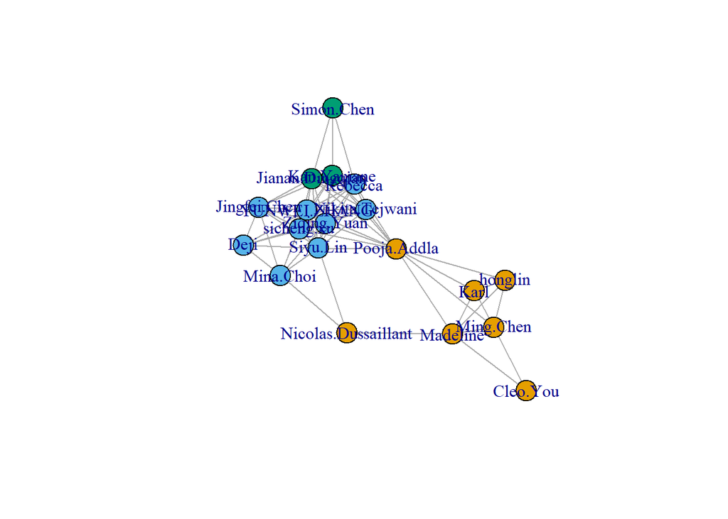

```r
V(g)$color <- fc$membership
plot(g)
```

## Make Your Network Prettier

Next, we are going to play with some network attributes to make our network prettier. Besides the coloring we have shown previously, we can manipulate the size and transparency of the nodes and edges.

The process is very similar: For example, if we want to use the display the node sizes based on the degree centrality, we first assign the obtained degree centrality measure to `V(g)`. And then we can use that in the `plot()`. Note here, we are multiplying the degree by 2 times so that it is decently large.

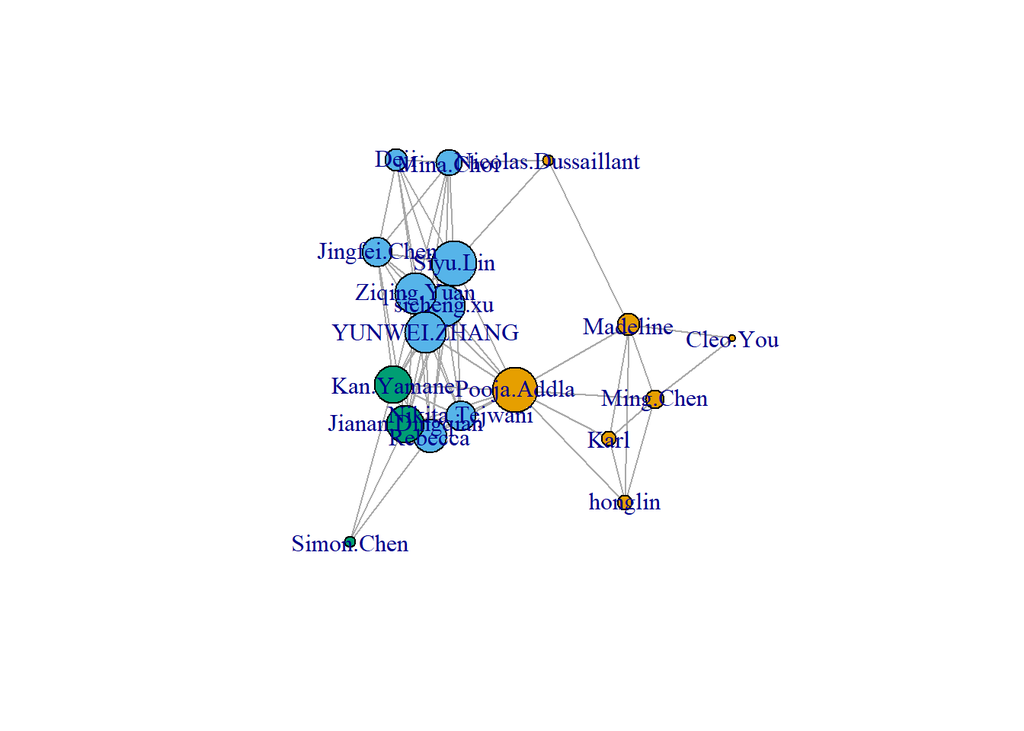

```r
V(g)$degree <- degree(g)

plot(g,
     vertex.size = V(g)$degree*2)
```

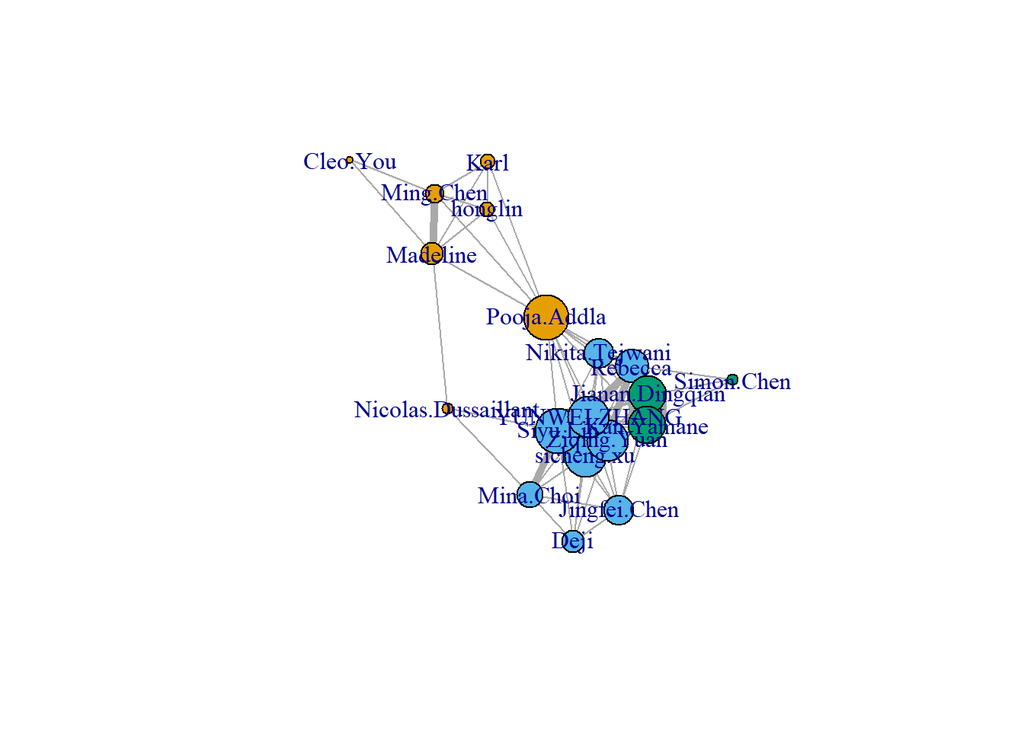

```r
plot(g,
     vertex.size = V(g)$degree*2,
     edge.width = 5^(E(g)$weight)/5)
```

Usually, algorithms try to minimize edge crossing and prevent overlap. Edges can have uniform length or not.

Choose your layout using the layout argument. Type `?igraph::layout` to see all the possibilities.

See here for an example: https://www.r-graph-gallery.com/247-network-chart-layouts.html

Now, let’s put everything together!

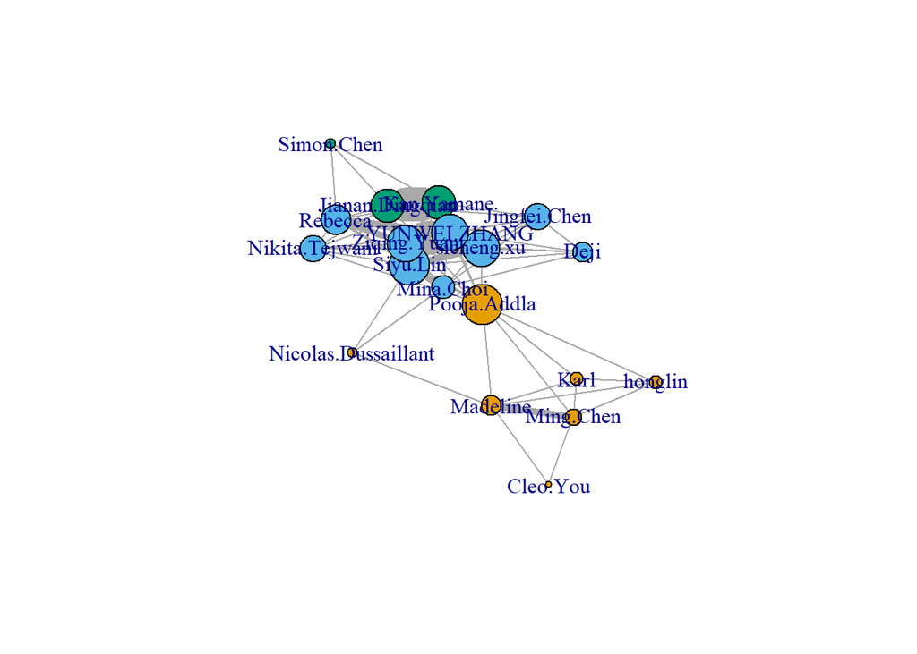

```r
# For consistent layout, you may want to set seed.
set.seed(123)

plot(g,
     vertex.size = V(g)$degree*2,
     edge.width = 5^(E(g)$weight)/5,
     layout=layout.fruchterman.reingold)
```

Drawing a nice plot can be really challenging. Some software (e.g., Gephi) automates the process fairly well and you can obtain the network statistics with just a couple of clicks. If you are tired of coding, feel free to give it a try.

Here are a couple of options for your reference, if you would like to give them a try:

- Gephi Download: https://gephi.org/
- Gephi Tutorial: https://www.youtube.com/watch?v=371n3Ye9vVo
- UCINET download (free trial for 3 months): https://sites.google.com/site/ucinetsoftware/home
- UCINET quick guide: https://depts.washington.edu/sociolab/researchtools/networkanalysis/documents/UCINetQuickGuide2018.pdf
- NodeXL (very good tool for social media analysis and can do lot of things including sentiment analysis): https://www.smrfoundation.org/nodexl/
- NodeXL quick start: https://youtu.be/mjAq8eA7uOM
- A wiki page on SNA tools: https://en.wikipedia.org/wiki/Social_network_analysis_software

## Your Tasks for ICE 8

For ICE 8, you may want to:

1. follow my tutorial and learn how to implement SNA.
2. think about what are you going to do with this method (e.g., implications and applications).
3. keep good record of your ICEs. Save the `.Rmd` files in a same place. You will need them later.